**Instructor copy.** Executed notebook with all results shown, including the "after your attempt" cells. Projector/offline fallback; learners should use the notebook itself.

# f5 · A binary in pycalphad

**Learning question:** how does pycalphad represent the invented A–B model from f3 and f4, and how do you read what `equilibrium` returns, before using it on a real alloy?

Used in: Lesson 8; before Task 01 (Cu–Ni); self-study before step 05 (optional). Do f4 first: here pycalphad must reproduce it. Labels such as (W4), (D1), (Lesson 5) or Clinic D point to the printed one-day primers (Day 1 and Day 2 worksheets) and the detailed lessons of the classroom course in the repository. Working alone on the website, you only need the step numbers.

**The route through the notebook.** In f3 and f4 you calculated the A–B model with your own formulas. Here the same model is handed to pycalphad, and every pycalphad number is compared with a value you already know. You will

1. read the database file and recognise each term of the model in it;
2. evaluate one phase at one composition with `calculate`;
3. find an equilibrium with `equilibrium` and learn to read its result;
4. scan temperature and draw a small miscibility gap.

Only once the tool reproduces known numbers is it used on a real alloy (Task 01).

Run the setup cell first; it makes the course code and the helper `check` available.

```python
# Setup: run this cell first. Locally it finds the course folder; in Colab it
# downloads the tested course release and the locked package versions.
# In Colab, the first run then restarts the session on purpose and Colab reports
# a crash: that is expected. Run this cell again, then the rest of the notebook.
RELEASE = "main"
import os, pathlib, subprocess, sys, time
ROOT = next((p for p in (pathlib.Path.cwd(), *pathlib.Path.cwd().parents)
             if (p / "pyproject.toml").is_file() and (p / "course").is_dir()), None)
if ROOT is None and "google.colab" in sys.modules:
    ROOT = pathlib.Path("/content/CalphadIntro")
    if not ROOT.is_dir():
        clone = ["git", "clone", "-q", "--depth", "1", "--branch", RELEASE,
                 "https://github.com/ukerzel/CalphadIntro.git", str(ROOT)]
        git = dict(os.environ, GIT_TERMINAL_PROMPT="0")
        if subprocess.run(clone, env=git, capture_output=True).returncode:
            raise SystemExit(f"Could not download course release {RELEASE}: check the internet "
                             "connection and run this cell again.")
    if not (ROOT / ".colab-ready").exists():
        if subprocess.run([sys.executable, "-m", "pip", "install", "-q", "-r",
                           str(ROOT / "notebooks" / "requirements-colab.txt")]).returncode:
            raise SystemExit("Installing the course packages failed; run this cell again.")
        (ROOT / ".colab-ready").touch()
        # Colab has already loaded its own numpy; a fresh session is needed to use the installed versions.
        print("Installed the course's package versions. Colab now restarts this session and"
              " reports a crash; that is expected. When it has reconnected, run this cell again"
              " (it will not install twice), then the rest of the notebook.", flush=True)
        time.sleep(3)
        os.kill(os.getpid(), 9)
if ROOT is None:
    raise SystemExit("Open this notebook from the course folder (poetry run jupyter lab) or in Colab.")
os.chdir(ROOT)
sys.path.insert(0, str(ROOT))
from notebooks.helpers import check, confirm, database, show_versions
show_versions(RELEASE)
```

```
Course release main · Python 3.12.14
  numpy       2.5.3
  scipy       1.18.1
  matplotlib  3.11.2
  xarray      2026.7.0
  pycalphad   0.11.2
```

```
True
```

## 1. Read the database before solving anything

Each phase has one set of sites that A or B can occupy, so the site fraction of B is the B atom fraction x. Compare the lines with f3: ALPHA's pure-A and pure-B energies are 1000 − 10T and 13000 − 10T (−9000 and +3000 J/mol at 1000 K); BETA has them swapped. `L(ALPHA,A,B;0)` is the interaction Ω, set by the function `LZERO` (0 in the file; the regular solution of f4 uses 20000 J/mol). The ideal mixing term RT·q(x) is added by pycalphad's phase model; it is not in the file.

**How to read a TDB file.** A database (TDB) file is plain text. Each command ends with `!`; lines starting with `$` are comments.

- `ELEMENT A ...` declares an element (here an invented one; its mass and reference data are placeholders).
- `FUNCTION LZERO 600 0; 1800 N !` defines a named function: from 600 K to 1800 K its value is `0`. `N` after the upper limit means "no further temperature range".
- `PHASE ALPHA % 1 1 !` declares a phase with **1** sublattice (set of sites) carrying **1** site per formula unit.
- `CONSTITUENT ALPHA :A,B: !` says that A or B can sit on that sublattice.
- `PARAMETER G(ALPHA,A;0) 600 1000-10*T; 1800 N !` is the Gibbs energy of pure A in the ALPHA structure, in J/mol, valid from 600 to 1800 K.
- `PARAMETER L(ALPHA,A,B;0) ...` is the interaction parameter of A and B in ALPHA; the `;0` marks the composition-independent (zeroth-order) term.

From these entries pycalphad builds the molar Gibbs energy of ALPHA at B fraction x (J/mol of atoms):

$$g_{\rm ALPHA}(x)=(1-x)\,G_{\rm A}+x\,G_{\rm B}+RT\,[x\ln x+(1-x)\ln(1-x)]+\Omega\,x(1-x),$$

the weighted pure-element energies, plus the ideal mixing term, plus the interaction term. This is the same formula you used in f3 and f4.

The cell below only prints the file. `Path` (from Python's `pathlib`) represents a file location; `.read_text()` returns the whole file as one string.

```python
from pathlib import Path

TDB = Path("course/foundations/binary_family.tdb")   # relative to the course folder (the setup cell moved there)
print(TDB.read_text())
```

```
$ Original synthetic binary teaching model; NOT assessed elemental data.
$ A/B are invented atoms. Mass/reference metadata below are placeholders.
$ Explicit wrapper domain: 600 <= T <= 1800 K; p=100000 Pa; mole-of-atoms basis.
$ I2: both ALPHA/BETA, LZERO=0. R1: ALPHA ONLY, override LZERO=20000.
$ Fit route: homogeneous ALPHA only, LZERO trial in [0,24000].
ELEMENT A BLANK 1.0 0.0 0.0 !
ELEMENT B BLANK 1.0 0.0 0.0 !
TYPE_DEFINITION % SEQ * !
FUNCTION LZERO 600 0; 1800 N !
PHASE ALPHA % 1 1 !
CONSTITUENT ALPHA :A,B: !
PARAMETER G(ALPHA,A;0) 600 1000-10*T; 1800 N !
PARAMETER G(ALPHA,B;0) 600 13000-10*T; 1800 N !
PARAMETER L(ALPHA,A,B;0) 600 LZERO; 1800 N !
PHASE BETA % 1 1 !
CONSTITUENT BETA :A,B: !
PARAMETER G(BETA,A;0) 600 13000-10*T; 1800 N !
PARAMETER G(BETA,B;0) 600 1000-10*T; 1800 N !
```

Find in the printout: the two `PHASE` lines, the four pure-element `G` parameters, the one `L` parameter, and the function `LZERO` it refers to. BETA has no `L` line, so it is always an ideal solution here.

## 2. One phase at one composition: `calculate`

`calculate` evaluates a phase at the compositions you give (`points` are site fractions [A, B]), stable or not. At 1000 K and x = 0.20 ALPHA should give the step 02 value.

First the file is read into a pycalphad `Database` object. Then the arguments of `calculate`, in order:

| Argument | Meaning |
| --- | --- |
| `database` | the model, as read from the TDB file |
| `["A", "B"]` | the components to include |
| `"ALPHA"` | the phase to evaluate (one name, or a list) |
| `T=1000, P=100000` | temperature in K and pressure in Pa |
| `N=1` | total amount: 1 mol of atoms |
| `points=np.array([[0.8, 0.2]])` | the states to evaluate: one row per state, one column per constituent in the order of the `CONSTITUENT` line (A, B); each row must add up to 1 |
| `output="GM"` | the property to compute: molar Gibbs energy, J/mol of atoms |
| `fake_points=False` | return only the points you asked for (no extra helper points) |

The result is an **xarray Dataset**: a set of named arrays whose axes have names (here `N`, `P`, `T` and `points`) instead of only numbers. `point.GM` is the GM array; `.values` turns it into a plain numpy array; `.squeeze()` removes all axes of length 1, leaving a single number that `float(...)` prints.

```python
import numpy as np
from pycalphad import Database, calculate, equilibrium, variables as v

database = Database(str(TDB))        # parse the TDB text into a model pycalphad can evaluate
point = calculate(database, ["A", "B"], "ALPHA", T=1000, P=100000, N=1,
                  points=np.array([[0.8, 0.2]]), output="GM", fake_points=False)   # site fractions y_A = 0.8, y_B = 0.2
print("ALPHA at x = 0.20, 1000 K: GM =", float(point.GM.values.squeeze()), "J/mol")
```

```
ALPHA at x = 0.20, 1000 K: GM = -10760.595950508265 J/mol
```

You can check this number by hand with the formula of section 1 (Ω = 0 here): weighted pure energies $0.8(-9000)+0.2(3000)=-6600$ J/mol, ideal mixing $8314.5\,[0.2\ln0.2+0.8\ln0.8]\approx-4161$ J/mol, total about −10761 J/mol.

### Your turn

Predict GM for **homogeneous** ALPHA at x = 0.5 and 1000 K with Ω = 0, in J/mol to 4 significant figures. Use R = 8.3145 J/(mol K). Then change `points` above to check.

"Homogeneous" means one single ALPHA solution at exactly this composition, whether or not it is the stable state; that is what `calculate` gives.

In the cell below, replace `None` by your number and run it. `check` says whether your value matches the stored one (to about four significant figures) without showing the stored value; with `None` it only reminds you to try.

```python
alpha_half = None  # J/mol
check(alpha_half, "f5_alpha_half")
```

```
f5_alpha_half: not attempted yet. Replace None with your value and run the cell again.
```

## 3. Reading an equilibrium result

`calculate` evaluates a phase where you tell it to. `equilibrium` instead searches for the state of lowest total Gibbs energy: it decides which phases are present, how much of each, and at which compositions.

`equilibrium` minimises G at fixed T, p, amount and overall composition z (here `v.X("B")`). The result is a labelled array (xarray) with one slot per **vertex**, a possible coexisting phase. pycalphad keeps one slot more than the number of components, so a binary has 3 vertex slots; slots that are not used have an empty phase name.

- `Phase`: phase name per vertex; an empty name `''` is an unused slot, not a phase
- `NP`: amount of each phase, per mole of atoms
- `X`: composition inside each phase
- `GM`: the minimum molar Gibbs energy of the whole sample

The result also holds `MU`, the chemical potential of each component (J/mol), and `Y`, the site fractions inside each phase; they are not used in this notebook.

**The conditions dictionary.** The fourth argument is a Python dictionary `{key: value, ...}` that fixes the state. The keys come from `pycalphad.variables`, imported as `v`:

| Key | Meaning | Value here |
| --- | --- | --- |
| `v.T` | temperature, K | 1000 |
| `v.P` | pressure, Pa | 100000 (1 bar) |
| `v.N` | total amount of atoms, mol | 1 |
| `v.X("B")` | overall mole fraction of B in the whole sample, z | 0.5 |

For a binary these four conditions fix the state completely; the overall fraction of A is then 1 − z. The third argument, `["ALPHA", "BETA"]`, lists the phases the search may use. A phase left out of this list can never appear in the answer.

**Shape of the result.** Every array has one axis per condition (`N`, `P`, `T`, `X_B`), each of length 1 here, then `vertex` (length 3) and, for `X`, also `component` (A, B). The first `print` shows these lengths. `.sel(component="B")` picks the B entries by name. `NP` is `nan` ("not a number") in an unused slot.

Two ideal phases ALPHA and BETA at z = 0.5 and 1000 K (f4 part A):

```python
result = equilibrium(database, ["A", "B"], ["ALPHA", "BETA"],
                     {v.T: 1000, v.P: 100000, v.N: 1, v.X("B"): 0.5})   # K, Pa, mol, overall B fraction
# Pair each axis name with its length, e.g. {'N': 1, 'P': 1, ...}.
print("dimensions:", dict(zip(result.Phase.dims, result.Phase.shape)))
print("GM    :", float(result.GM.values.squeeze()))              # J/mol of atoms, whole sample
print("Phase :", result.Phase.values.squeeze())                  # one name per vertex slot
print("NP    :", result.NP.values.squeeze())                     # mol of each phase per mol of atoms
print("X(B)  :", result.X.sel(component="B").values.squeeze())   # B fraction inside each phase
```

```
dimensions: {'N': 1, 'P': 1, 'T': 1, 'X_B': 1, 'vertex': 3}
GM    : -10762.73001746401
Phase : ['ALPHA' 'BETA' '']
NP    : [0.5 0.5 nan]
X(B)  : [0.19104075 0.80895925        nan]
```

Read the output column by column: slot 0 and slot 1 are used (ALPHA and BETA), slot 2 is empty. The amounts `NP` of the used slots add up to 1 mol, and the two `X(B)` values lie on either side of z = 0.5. That is the two-phase split you found in f4 part A. A mass balance check you can do in your head: the amounts times the compositions must add up to z.

### Your turn

Now allow **only ALPHA** but give it Ω = 20000 J/mol (`parameters={"LZERO": 20000}`), at the same T and z. Before running: how many used vertices will there be, and what phase name will they have?

Think back to the regular solution of f4 at 1000 K before you answer. Enter your count in the next cell; the cell after it runs the calculation.

```python
used_vertices = None  # how many non-empty Phase entries
check(used_vertices, "f5_r1_vertices")
```

```
f5_r1_vertices: not attempted yet. Replace None with your value and run the cell again.
```

The next cell runs that calculation. `parameters={"LZERO": 20000}` replaces the value of the function `LZERO` for this one call; the file itself is not changed.

The `for` loop walks through the three vertex slots together: `zip(a, b, c)` hands out the first entries of the three arrays, then the second entries, and so on. `if phase:` skips the unused slots, because an empty text `''` counts as False in Python.

```python
regular = equilibrium(database, ["A", "B"], ["ALPHA"],
                      {v.T: 1000, v.P: 100000, v.N: 1, v.X("B"): 0.5},
                      parameters={"LZERO": 20000})   # Ω = 20000 J/mol for this call only
for phase, amount, x in zip(regular.Phase.values.squeeze(), regular.NP.values.squeeze(),
                            regular.X.sel(component="B").values.squeeze()):
    if phase:   # skip empty slots
        print(f"{phase}: amount {amount:.4f}, x(B) = {x:.6f}")
```

```
ALPHA: amount 0.5000, x(B) = 0.169144
ALPHA: amount 0.5000, x(B) = 0.830856
```

Two rows with the same name ALPHA: one phase model, two compositions (the miscibility gap of f4). Storing results in a dictionary keyed by phase name would silently keep only one of them. The energy GM belongs to the whole sample: do not add it once per row.

The two compositions lie symmetrically about 0.5 because this model is symmetric in A and B apart from the linear term, which does not affect where the gap is.

## 4. From one point to a scan to a small diagram

Conditions can be arrays. One call scans temperature at z = 0.3; collecting the two compositions at each temperature draws the gap you built by hand in f4.

`np.arange(600.0, 1201.0, 50.0)` gives 600, 650, …, 1200 K (the stop value 1201 itself is not included). Passing this array as `v.T` makes pycalphad solve all 13 temperatures in one call; the `T` axis of the result then has length 13.

To read one temperature, the loop indexes the arrays by position: `scan.Phase.values[0, 0, i, 0]` means N slot 0, P slot 0, temperature number `i`, X_B slot 0, and all vertex slots. `enumerate(temperatures)` gives the position `i` together with the value `T`.

For every temperature with two used slots, the loop stores the lower and the higher composition in the list `gap` as a tuple `(T, x_low, x_high)`; these are the two sides of the miscibility gap at that temperature.

```python
temperatures = np.arange(600.0, 1201.0, 50.0)   # K: 600, 650, …, 1200
scan = equilibrium(database, ["A", "B"], ["ALPHA"],
                   {v.T: temperatures, v.P: 100000, v.N: 1, v.X("B"): 0.3},
                   parameters={"LZERO": 20000})
gap = []   # will hold (T, lower x(B), upper x(B)) wherever two compositions coexist
print(" T (K)   phases and compositions x(B)")
for i, T in enumerate(temperatures):
    phases = scan.Phase.values[0, 0, i, 0]                   # 3 phase names (vertex slots) at this T
    xs = scan.X.sel(component="B").values[0, 0, i, 0]        # B fraction in each slot
    used = [(str(p), float(x)) for p, x in zip(phases, xs) if p]   # keep only the used slots
    print(f"{T:6.0f}   " + ", ".join(f"{p} {x:.4f}" for p, x in used))
    if len(used) == 2:   # two coexisting compositions: a point on each side of the gap
        gap.append((T, min(x for _, x in used), max(x for _, x in used)))
```

```
 T (K)   phases and compositions x(B)
   600   ALPHA 0.0210, ALPHA 0.9790
   650   ALPHA 0.0299, ALPHA 0.9701
   700   ALPHA 0.0409, ALPHA 0.9591
   750   ALPHA 0.0542, ALPHA 0.9458
   800   ALPHA 0.0701, ALPHA 0.9299
   850   ALPHA 0.0890, ALPHA 0.9110
   900   ALPHA 0.1113, ALPHA 0.8887
   950   ALPHA 0.1376, ALPHA 0.8624
  1000   ALPHA 0.1691, ALPHA 0.8309
  1050   ALPHA 0.2074, ALPHA 0.7926
  1100   ALPHA 0.2557, ALPHA 0.7443
  1150   ALPHA 0.3000
  1200   ALPHA 0.3000
```

Read the table from the top: at low temperature z = 0.3 splits into two compositions; as T rises, the two compositions move towards each other.

### Your turn

Above which temperature in this scan is z = 0.3 a single phase? (Give the lowest scanned temperature with one phase, in K.) Why is that below the critical temperature of about 1203 K, where the gap closes at x = 0.5?

The critical temperature of the regular solution is $T_c=\Omega/(2R)$; with Ω = 20000 J/mol this is about 1203 K.

```python
first_single_phase = None  # K
check(first_single_phase, "f5_single_phase_t")
```

```
f5_single_phase_t: not attempted yet. Replace None with your value and run the cell again.
```

## After your attempt: pycalphad against the plain model, and three wrong problems

The next cell does three things.

1. **Compare.** `confirm` checks the pycalphad numbers of this notebook against the course's own plain-Python model (`binary_family`), which uses the formulas of f3 and f4. `regular_binodal(T)` returns the two gap compositions at temperature T.
2. **Three wrong problems** (Lesson 8.4). Each one gives a correct answer to a different question:
   - leaving BETA out of the phase list: pycalphad then finds the best state with ALPHA alone, which is higher in energy than the true equilibrium with BETA;
   - forgetting Ω: the homogeneous energy is lower by exactly $\Omega\,x(1-x)=20000\cdot0.25=5000$ J/mol at x = 0.5;
   - using the enthalpy of the equilibrium split as if it were the homogeneous enthalpy (you meet this again in f6).
3. **Plot.** The grey lines are the gap from the plain model on a fine temperature grid; the markers are the pycalphad compositions from the scan of section 4. The dotted vertical line marks z = 0.3. Where the markers sit on the lines, pycalphad and the plain model agree.

```
✓ ALPHA at x = 0.20 (step 02) reproduces the lesson value.
✓ Two-phase minimum at z = 0.5 (step 03) reproduces the lesson value.
✓ Gap composition at 1000 K, pycalphad vs plain model reproduces the lesson value.
Three ways to answer a different question (Lesson 8.4):
```

```
  BETA left out: -8763.172233 J/mol instead of -10762.730017
✓ ALPHA-only result (a different question) reproduces the lesson value.
  Ω forgotten: homogeneous GM -8763.172233 instead of -3763.172233 (lower by 5000 J/mol)
✓ Ω·x(1−x) at x = 0.5 reproduces the lesson value.
  Enthalpy of the equilibrium split is not the homogeneous enthalpy: equilibrium minimises G, not H.
```

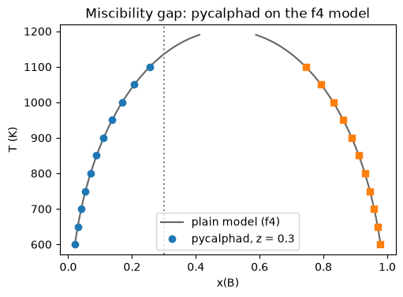

```python
#@title After your attempt: run to compare and plot
import matplotlib.pyplot as plt
from course.foundations import binary_family as plain
from course.foundations.binary_family_tools import binary_equilibrium, homogeneous_properties

# 1. pycalphad results of this notebook against the lesson values (J/mol).
confirm(float(point.GM.values.squeeze()), -10760.595951, "ALPHA at x = 0.20 (step 02)", tol=1e-6)
confirm(float(result.GM.values.squeeze()), -10762.730017, "Two-phase minimum at z = 0.5 (step 03)", tol=1e-5)
# The two gap compositions found by pycalphad, sorted from low to high x(B).
xs = sorted(float(x) for p, x in zip(regular.Phase.values.squeeze(), regular.X.sel(component="B").values.squeeze()) if p)
reference = plain.regular_binodal(1000.0)["compositions"]   # the same gap from the plain formulas
confirm(xs[0], reference[0], "Gap composition at 1000 K, pycalphad vs plain model", tol=1e-6)

# 2. Three ways to answer a different question.
print("Three ways to answer a different question (Lesson 8.4):")
with_beta = binary_equilibrium(1000.0, 0.5, "I2")["GM"]   # "I2": ALPHA and BETA allowed, Ω = 0
alpha_only = equilibrium(database, ["A", "B"], ["ALPHA"], {v.T: 1000, v.P: 100000, v.N: 1, v.X("B"): 0.5})
print(f"  BETA left out: {float(alpha_only.GM.values.squeeze()):.6f} J/mol instead of {with_beta:.6f}")
confirm(float(alpha_only.GM.values.squeeze()), -8763.172233, "ALPHA-only result (a different question)", tol=1e-5)
with_omega = float(homogeneous_properties(1000.0, 0.5, "ALPHA", 20000.0)["GM"])   # homogeneous ALPHA, Ω = 20000
without_omega = float(homogeneous_properties(1000.0, 0.5, "ALPHA", 0.0)["GM"])    # homogeneous ALPHA, Ω = 0
print(f"  Ω forgotten: homogeneous GM {without_omega:.6f} instead of {with_omega:.6f} (lower by {with_omega - without_omega:.0f} J/mol)")
confirm(with_omega - without_omega, 5000.0, "Ω·x(1−x) at x = 0.5", tol=1e-6)
print("  Enthalpy of the equilibrium split is not the homogeneous enthalpy: equilibrium minimises G, not H.")

# 3. Plot: plain-model gap (lines) and pycalphad scan (markers).
T_fine = np.linspace(600, 1190, 60)                                 # K, stays below the critical temperature
pairs = [plain.regular_binodal(T)["compositions"] for T in T_fine]  # (left, right) gap edges at each T
fig, ax = plt.subplots(figsize=(5.5, 3.8))
ax.plot([p[0] for p in pairs], T_fine, "-", color="0.4", label="plain model (f4)")   # left edge; color "0.4" is a grey
ax.plot([p[1] for p in pairs], T_fine, "-", color="0.4")                             # right edge
ax.plot([g[1] for g in gap], [g[0] for g in gap], "o", label="pycalphad, z = 0.3")   # lower x(B) from the scan
ax.plot([g[2] for g in gap], [g[0] for g in gap], "s")                               # upper x(B) from the scan
ax.axvline(0.3, ls=":", color="0.5")   # vertical line at the overall composition z = 0.3
ax.set(xlabel="x(B)", ylabel="T (K)", title="Miscibility gap: pycalphad on the f4 model")
ax.legend()
plt.show()
```

**Limits.** The same invented model as f3/f4; agreement shows pycalphad reads it as intended, not that it describes a real alloy. The equilibrium search samples trial compositions and refines them (the `pdens` setting you will meet in Task 01). Next: Task 01 · Cu–Ni equilibria.